# My Manuscript

Created in Rmarkdown

23 mar 2022 16:54:21 -03

Abstract

## Material and methods

```r
require(factoextra)
require(cluster)
require(tidyverse)
require(terra)
require(raster)
require(sp)
require(randomForest)
require(knitr)
```

The study is based on the ForestPlots plot network, including recent plots where giant trees were reported in the Brazilian Amazon (https://www.forestplots.net/). The plots were monitored by different research teams (Appendix S3). Within the plots, each tree had its diameter (d) recorded. We filtered out plots where less than 90% of the trees have been identified, at least at genus level. Botanical identification was harmonized using the Taxonomic Name Resolution Service (https://tnrs.iplantcollaborative.org), Missouri Botanical Garden (https://www.missouribotanicalgarden.org/), and Flora package in R.

Each tree in the dataset was associated to a basic wood density using the lowest available taxonomic level of botanical identifications (i.e. species or genus) and the corresponding average wood density recorded in the Global Wood Density Database (GWDD; Chave et al., 2009; Zanne et al., 2009). The plots were totalized in terms of structure and diversity. The diversity was computed using the Shannon index, for species, genus and family level. The structural attributes were computed to mean, maximum and standard deviation for diameter; and mean and standard deviation for basic wood density.

```r
full = read.csv2('C:/Users/User/Insync/eric.gorgens@ufvjm.edu.br/Google Drive/pesquisa/paper e orientações/eba transectos lidar/2022 - Robson - Agrupamento estrutura e diversidade/dados_full_10cm.csv')
full[full$site == 'STO','site'] <- 'STO.P'
full[full$site == 'STP','site'] <- 'STO.P'
full[full$site == 'MUF','site'] <- 'MUF.U'
full[full$site == 'MUU','site'] <- 'MUF.U'
full[full$site == 'ETB','site'] <- 'ETA'
full[full$site == 'ETE','site'] <- 'ETA'
full[full$site == 'ETF','site'] <- 'ETA'
```

```r
fullSpecies = full %>% filter(species != 'Indet.') %>%
  filter(epiteto != 'sp.') %>%
  filter(epiteto != 'indet')

species10 = fullSpecies %>% group_by(species) %>%
  summarise(trees = n()/nrow(full) * 100) %>%
  arrange(desc(trees))

species70 = fullSpecies %>% filter(d >= 70) %>%
  group_by(species) %>%
  summarise(trees = n()/nrow(full) * 100) %>%
  arrange(desc(trees))
```

```r
shannon = function(vector){
  termo1 = -1 * table(vector)/length(vector)
  termo2 = log(table(vector)/length(vector))
  H = sum(termo1 * termo2)
}
```

```r
dados10 = full %>% group_by(site) %>%
  summarise(spH_10 = shannon(species),
            genH_10 = shannon(genero),
            famH_10 = shannon(family),
            dmean_10 = mean(d),
            dmax_10 = max(d),
            dsd_10 = sd(d),
            wdmean_10 = mean(wd),
            wdsd_10 = sd(wd))
```

```r
dados70 = full %>% filter(d >= 70) %>%
  group_by(site) %>%
  summarise(spH_70 = shannon(species),
            genH_70 = shannon(genero),
            famH_70 = shannon(family),
            dmean_70 = mean(d),
            dmax_70 = max(d),
            dsd_70 = sd(d),
            wdmean_70 = mean(wd),
            wdsd_70 = sd(wd))
```

```r
esp10 = full %>% filter(species %in% head(species10$species, 50)) %>%
  group_by(site, species) %>%
  summarise(n = n() / length(full$species) * 100) %>%
  spread(species, n)


esp10[is.na(esp10)] <- 0
```

```r
esp70 = full %>% filter(species %in% head(species70$species, 50)) %>%
  group_by(site, species) %>%
  summarise(n = n() / length(full$species) * 100) %>%
  spread(species, n)


esp70[is.na(esp70)] <- 0
```

To explore patterns between the plots considering structure and diversity, we implemented the k-means analysis with increasing numbers of clusters. The groups were built base on the attributes of structure (d and wood density) and diversity (species, genus and family diversity, and the relative density of top 50 species) considering all trees (d >= 10 cm) and big trees (d >= 70 cm). The algorithm compares the source dataset and synthetic datasets with similar distribution properties to determine the interrelationships between the attributes through their dimensions (components).

```r
sitioCoord = read.csv('dados/siteForestPlots_en.csv')
```

```r
tokmeans = merge(sitioCoord, dados10, by.x = 'Site', by.y = 'site', all = TRUE)
tokmeans = merge(tokmeans, dados70, by.x = 'Site', by.y = 'site', all = TRUE)
tokmeans = merge(tokmeans, esp10, by.x = 'Site', by.y = 'site', all = TRUE, suffixes = c(".x","_10"))
tokmeans = merge(tokmeans, esp70, by.x = 'Site', by.y = 'site', all = TRUE, suffixes = c("_10","_70"))
row.names(tokmeans) = tokmeans$Site
tokmeans[is.na(tokmeans)] <- 0
tokmeans = tokmeans[, c(8:123)]
tokmeans <- scale(tokmeans)
```

```r
#calculate gap statistic based on number of clusters
gap_stat <- clusGap(tokmeans,
                    FUN = kmeans,
                    nstart = 25,
                    K.max = 10,
                    B = 50)
```

```r
km <- kmeans(tokmeans, centers = 4, nstart = 25)
```

Based on the geolocation, each site was associated to its respective biogeographic region proposed by Morrone (2014). The Morrone’s regions considered terrestrial plant and animal taxa to divide the Brazilian Amazon into eight regions. We exclude three biogeographic regions (i.e. Pantepui, Guianan Lowlands and Cerrado) due to single site occurrence. We used the biogeographical regions to explore structural and diversity characteristics which differentiating each of them. Furthermore, we explored the differences between the regions, analyzing the two contexts separately. The diversity and structural attributes for each context were used to classify the regions using a random forest algorithm, followed by analysis of importance of the variables.

```r
toRf10 = merge(sitioCoord, dados10, by.x = 'Site', by.y = 'site', all = TRUE)
toRf10 = merge(toRf10, esp10, by.x = 'Site', by.y = 'site', all = TRUE)
```

```r
coordinates(toRf10) <- ~Longitude+Latitude
proj4string(toRf10) <- CRS("+proj=longlat +datum=WGS84 +no_defs +ellps=WGS84 +towgs84=0,0,0")
```

```r
morrone = shapefile('dados/Morrones.shp', encoding = 'UTF-8')
morrone = spTransform(morrone, crs(toRf10))
```

```r
toRf10 = cbind(toRf10, over(toRf10, morrone))
```

```r
distrib = toRf10@data %>% group_by(Province_1) %>% summarise(sites = n())

kable(distrib, digits = 0, col.names = c("Region", "Number of sites"), caption = 'Number of sites by biogegraphic region proposed by Morrone (2014)')
```

Number of sites by biogegraphic region proposed by Morrone (2014)

| Region | Number of sites |
| --- | --- |
| Cerrado province | 1 |
| Guianan Lowlands province | 1 |
| Madeira province | 19 |
| Pantepui province | 1 |
| Pará province | 8 |
| Rondônia province | 8 |
| Roraima province | 10 |
| Xingu-Tapajós province | 17 |

```r
toRf10 = toRf10@data %>% filter(Province_1 %in% c("Madeira province", "Pará province", "Roraima province", "Xingu-Tapajós province", "Rondônia province"))

toRf10 = toRf10[, c(6:63, 67)]
toRf10[is.na(toRf10)] <- 0
```

```r
toRf70 = merge(sitioCoord, dados70, by.x = 'Site', by.y = 'site', all = TRUE)
toRf70 = merge(toRf70, esp70, by.x = 'Site', by.y = 'site', all = TRUE)
```

```r
coordinates(toRf70) <- ~Longitude+Latitude
proj4string(toRf70) <- CRS("+proj=longlat +datum=WGS84 +no_defs +ellps=WGS84 +towgs84=0,0,0")
```

```r
morrone = spTransform(morrone, crs(toRf70))
```

```r
toRf70 = cbind(toRf70, over(toRf70, morrone))
```

```r
toRf70 = toRf70@data %>% filter(Province_1 %in% c("Madeira province", "Pará province", "Roraima province", "Xingu-Tapajós province", "Rondônia province"))

toRf70 = toRf70[, c(6:63, 67)]
toRf70[is.na(toRf70)] <- 0
```

```r
rf10 = randomForest(factor(Province_1)~., data = toRf10, importance=TRUE, scale = TRUE)
```

```r
rf70 = randomForest(factor(Province_1)~., data = toRf70, importance=TRUE, scale = TRUE)
```

We analyzed the variable importance by permuting data. For each tree, the prediction error on the out-of-bag portion of the data is recorded (error rate for classification). Then the same is done after permuting each predictor variable. The difference between the two are then averaged over all trees, and normalized by the standard deviation of the differences. We considered two indicators of variable importance: decrease in average accuracy, and decrease in gini importance (mean decrease impurity). The analyzes were performed in R environment, with the help of packages randomForest and terra.

## Results

```r
require(factoextra)
require(cluster)
require(tidyverse)
require(terra)
require(raster)
require(sp)
require(randomForest)
require(knitr)
```

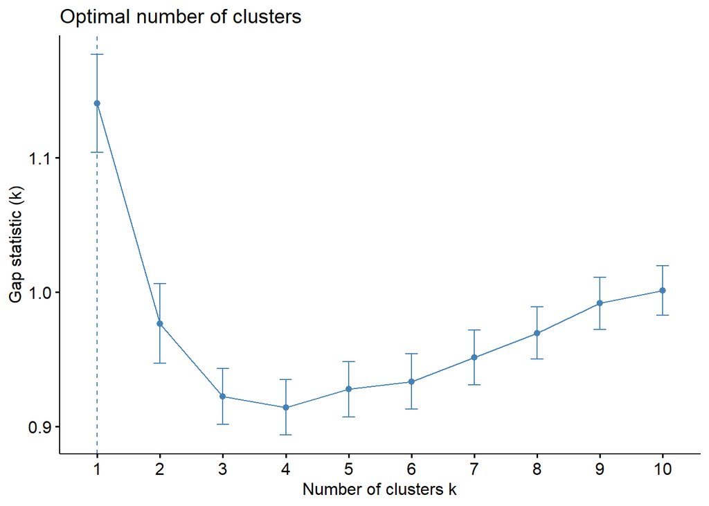

```r
#plot number of clusters vs. gap statistic
fviz_gap_stat(gap_stat)
```

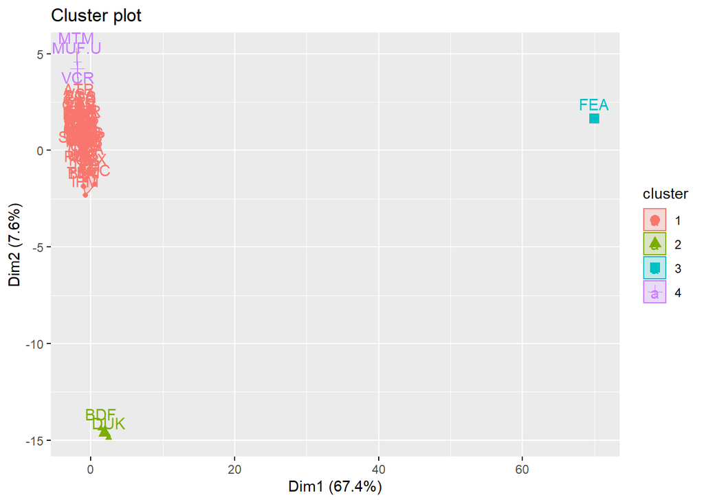

```r
fviz_cluster(km, data = tokmeans)
```

```r
pca <- prcomp(tokmeans,  scale = TRUE)
kable(pca$rotation[,1:2], digits = 2, caption = 'Loadings of two main principal components.')
```

Loadings of two main principal components.

|  | PC1 | PC2 |
| --- | --- | --- |
| spH_10 | 0.01 | -0.21 |
| genH_10 | 0.01 | -0.16 |
| famH_10 | 0.01 | -0.14 |
| dmean_10 | 0.08 | 0.04 |
| dmax_10 | 0.02 | -0.03 |
| dsd_10 | 0.03 | 0.04 |
| wdmean_10 | 0.01 | -0.12 |
| wdsd_10 | 0.01 | -0.05 |
| spH_70 | 0.04 | -0.21 |
| genH_70 | 0.04 | -0.19 |
| famH_70 | 0.03 | -0.18 |
| dmean_70 | 0.00 | 0.02 |
| dmax_70 | 0.02 | -0.04 |
| dsd_70 | 0.00 | 0.01 |
| wdmean_70 | 0.01 | -0.13 |
| wdsd_70 | 0.01 | -0.07 |
| Alexa grandiflora_10 | 0.11 | 0.03 |
| Brosimum rubescens | 0.00 | -0.05 |
| Carapa guianensis_10 | 0.11 | 0.02 |
| Conceveiba guianensis_10 | 0.11 | 0.00 |
| Ecclinusa lanceolata | 0.11 | 0.02 |
| Eperua rubiginosa_10 | 0.11 | 0.02 |
| Eschweilera coriacea_10 | 0.11 | -0.08 |
| Eschweilera odora | 0.00 | -0.04 |
| Eschweilera pedicellata_10 | 0.11 | 0.00 |
| Eschweilera truncata | 0.00 | -0.30 |
| Eschweilera wachenheimii | 0.00 | -0.30 |
| Euterpe precatoria | 0.00 | -0.07 |
| Goupia glabra_10 | 0.11 | -0.01 |
| Guarea pubescens_10 | 0.11 | 0.02 |

[output cut: 86 more lines]

```r
kable(importance(rf10), digits = 2, col.names = c('Madeira', 'Pará', 'Rondônia', 'Roraima', 'Xingu-Tapajos', 'Decrease Accuracy', 'Decrease Gini') ,caption = 'Variable importace to classfy by province, and for general random forest performance.')
```

Variable importace to classfy by province, and for general random forest performance.

|  | Madeira | Pará | Rondônia | Roraima | Xingu-Tapajos | Decrease Accuracy | Decrease Gini |
| --- | --- | --- | --- | --- | --- | --- | --- |
| spH_10 | 5.01 | 1.96 | 2.67 | 0.99 | 3.93 | 7.10 | 2.02 |
| genH_10 | 1.83 | 0.29 | 6.24 | 0.53 | 3.43 | 6.09 | 2.44 |
| famH_10 | 5.12 | 1.01 | 6.13 | 1.06 | 1.00 | 7.18 | 2.22 |
| dmean_10 | 1.50 | 0.65 | -0.01 | 0.20 | -0.96 | 1.01 | 1.59 |
| dmax_10 | -1.25 | 1.69 | -0.33 | 2.84 | 1.62 | 1.00 | 1.62 |
| dsd_10 | -1.59 | -0.70 | -0.26 | 1.85 | -1.48 | -0.96 | 1.35 |
| wdmean_10 | 7.68 | 1.88 | 6.86 | 6.13 | 2.84 | 11.41 | 3.08 |
| wdsd_10 | 2.71 | 4.16 | -1.48 | 5.04 | -0.94 | 3.81 | 1.93 |
| Alexa.grandiflora | 1.41 | 0.00 | 0.00 | 0.00 | 2.53 | 2.94 | 0.40 |
| Brosimum.rubescens | -0.56 | 1.61 | 2.30 | 3.41 | 0.67 | 2.73 | 0.84 |
| Carapa.guianensis | -0.10 | 2.55 | 1.42 | 0.29 | -1.22 | 0.85 | 0.44 |
| Conceveiba.guianensis | 0.28 | 0.16 | 0.38 | 1.27 | -0.14 | 0.67 | 0.44 |
| Ecclinusa.lanceolata | 0.00 | 0.00 | -0.45 | 0.00 | 1.00 | 0.62 | 0.14 |
| Eperua.rubiginosa | 0.00 | 0.00 | 0.00 | 0.00 | 0.00 | 0.00 | 0.00 |
| Eschweilera.coriacea | -0.08 | 4.00 | 0.76 | 1.01 | 2.56 | 3.11 | 1.06 |
| Eschweilera.odora | 1.00 | 0.00 | 0.00 | -1.40 | -1.00 | -1.20 | 0.09 |
| Eschweilera.pedicellata | -1.54 | -1.03 | -1.00 | -1.13 | 0.17 | -1.55 | 0.34 |
| Eschweilera.truncata | 0.43 | 0.00 | 1.00 | 1.70 | 0.00 | 1.90 | 0.10 |
| Eschweilera.wachenheimii | -1.00 | 0.00 | 1.00 | 1.60 | 1.36 | 1.19 | 0.05 |
| Euterpe.precatoria | 1.30 | 3.46 | 5.56 | 2.33 | 6.48 | 7.43 | 2.01 |
| Goupia.glabra | 0.01 | 1.46 | 4.24 | 4.24 | 4.55 | 5.28 | 1.38 |
| Guarea.pubescens | -1.00 | 0.00 | 0.00 | -1.73 | -1.41 | -2.45 | 0.10 |
| Inga.auristellae | -1.00 | 1.00 | 0.00 | -0.79 | -0.43 | -0.84 | 0.17 |
| Iriartea.deltoidea | -1.03 | 2.17 | 5.84 | 2.39 | 2.50 | 6.16 | 1.18 |
| Iryanthera.paraensis | 0.00 | -1.00 | 0.00 | 0.00 | 0.00 | -1.00 | 0.07 |
| Lecythis.idatimon | 5.52 | 9.92 | 2.27 | 2.99 | 4.31 | 10.46 | 1.93 |
| Lecythis.lurida | 2.22 | 0.91 | 0.00 | -1.42 | 0.46 | 1.19 | 0.17 |
| Licania.canescens | -0.39 | 0.45 | 1.99 | -0.80 | 1.88 | 1.73 | 0.39 |
| Licania.heteromorpha | 1.87 | -0.30 | -0.18 | -0.59 | -1.62 | 0.03 | 0.67 |
| Licania.octandra | 2.43 | 1.79 | 2.04 | 2.25 | 1.40 | 3.95 | 0.62 |
| Metrodorea.flavida | -1.07 | 1.64 | -1.36 | 1.34 | 1.58 | 0.10 | 0.84 |
| Micropholis.acutangula | 0.59 | 2.26 | 1.38 | -0.18 | 2.00 | 2.81 | 0.36 |
| Micropholis.guyanensis | 2.35 | 1.50 | 1.06 | 2.06 | -2.16 | 2.03 | 0.62 |
| Micropholis.longipedicellata | 0.00 | 0.00 | 0.00 | 0.00 | 0.00 | 0.00 | 0.00 |
| Micropholis.venulosa | 1.01 | -0.65 | 0.87 | 0.66 | 1.87 | 2.24 | 0.56 |
| Minquartia.guianensis | 3.77 | 0.36 | -0.70 | 5.41 | 0.43 | 5.34 | 1.73 |
| Mouriri.apiranga | 0.79 | 1.00 | 0.00 | 0.00 | -0.33 | 0.60 | 0.13 |
| Neoxythece.elegans | 0.00 | 0.00 | 0.00 | 0.00 | 0.00 | 0.00 | 0.16 |
| Oenocarpus.bacaba | 2.25 | 1.64 | 2.33 | 7.28 | 2.36 | 7.19 | 1.17 |
| Oenocarpus.bataua | 1.30 | 2.39 | 0.72 | -0.36 | 3.95 | 3.42 | 0.74 |
| Pouteria.caimito | 1.52 | 1.09 | -1.27 | -0.49 | -1.23 | 0.22 | 0.65 |
| Protium.altsonii | 1.49 | 2.06 | 2.37 | 2.04 | 2.04 | 4.19 | 0.79 |
| Protium.apiculatum | 0.18 | 1.28 | 2.49 | 1.79 | 1.14 | 2.51 | 0.58 |
| Protium.decandrum | 1.15 | 2.82 | 2.77 | 1.75 | 1.45 | 4.25 | 0.76 |
| Protium.hebetatum | 0.96 | 1.94 | 0.00 | 4.37 | 0.52 | 3.66 | 0.39 |
| Protium.tenuifolium | 0.94 | 2.24 | 2.86 | 1.36 | 0.47 | 3.07 | 0.60 |
| Pseudolmedia.laevis | -2.60 | 2.73 | 3.59 | 1.43 | 1.10 | 2.09 | 0.87 |
| Rinorea.guianensis | 0.53 | 1.72 | 2.17 | 1.52 | 1.50 | 2.84 | 0.51 |
| Sagotia.brachysepala | 0.00 | 0.00 | 0.00 | 0.00 | 0.00 | 0.00 | 0.01 |
| Scleronema.micranthum | 0.25 | 1.41 | 1.34 | 3.10 | 2.97 | 3.96 | 0.62 |
| Sloanea.grandiflora | 0.31 | 2.94 | 2.12 | 2.47 | 0.49 | 3.44 | 0.37 |
| Symphonia.globulifera | 1.28 | 3.04 | 3.14 | 4.00 | 1.27 | 5.13 | 1.08 |
| Tabebuia.serratifolia | -1.25 | 0.61 | 2.87 | 0.21 | 0.88 | 1.45 | 0.58 |
| Tachigali.myrmecophila | 1.58 | -0.12 | 2.11 | 4.07 | 2.09 | 4.50 | 0.76 |
| Tetragastris.altissima | 0.67 | 1.24 | 0.26 | 0.30 | 0.20 | 1.12 | 0.59 |
| Theobroma.speciosum | -0.04 | 0.39 | 2.36 | 2.57 | 2.87 | 3.56 | 1.30 |
| Virola.michelii | 2.37 | 0.47 | 3.66 | -0.87 | 0.25 | 2.47 | 1.13 |
| Vouacapoua.americana | 0.00 | 0.00 | 0.00 | 0.00 | 1.95 | 2.00 | 0.05 |

```r
kable(importance(rf70), digits = 2, col.names = c('Madeira', 'Pará', 'Rondônia', 'Roraima', 'Xingu-Tapajos', 'Decrease Accuracy', 'Decrease Gini') ,caption = 'Variable importace to classfy by province, and for general random forest performance.')
```

Variable importace to classfy by province, and for general random forest performance.

|  | Madeira | Pará | Rondônia | Roraima | Xingu-Tapajos | Decrease Accuracy | Decrease Gini |
| --- | --- | --- | --- | --- | --- | --- | --- |
| spH_70 | -0.73 | 0.61 | -1.27 | 2.41 | 1.84 | 0.89 | 1.90 |
| genH_70 | -0.80 | 1.44 | -1.43 | 2.43 | 1.85 | 0.65 | 1.85 |
| famH_70 | -0.19 | -0.14 | 0.64 | 4.05 | 0.56 | 1.74 | 1.75 |
| dmean_70 | -2.96 | 1.03 | -0.97 | -0.64 | -0.54 | -2.96 | 1.66 |
| dmax_70 | -2.00 | 1.59 | -1.45 | 0.72 | 0.22 | -1.08 | 1.93 |
| dsd_70 | 1.49 | 0.70 | -1.80 | 0.54 | -1.56 | -0.17 | 1.80 |
| wdmean_70 | 1.29 | -0.63 | 5.25 | 7.48 | -1.58 | 5.44 | 2.92 |
| wdsd_70 | 0.83 | -2.45 | -0.30 | 2.02 | -1.26 | -0.21 | 1.89 |
| Abarema.jupunba | 2.22 | 0.28 | 1.99 | -0.37 | -2.56 | 0.49 | 0.50 |
| Alexa.grandiflora | 1.93 | 1.00 | 0.00 | 1.00 | 3.20 | 3.43 | 0.55 |
| Aspidosperma.excelsum | -0.60 | 2.16 | 1.21 | -0.33 | 2.23 | 2.27 | 0.42 |
| Bertholletia.excelsa | 1.67 | 2.88 | -2.36 | 0.86 | 1.83 | 1.11 | 1.07 |
| Bowdichia.nitida | 1.84 | 1.40 | 0.00 | -1.00 | -0.23 | 1.54 | 0.23 |
| Brosimum.parinarioides | 1.19 | 1.93 | 2.17 | 3.11 | 0.43 | 3.54 | 0.66 |
| Carapa.guianensis | 1.36 | 3.15 | 1.04 | 1.10 | -1.02 | 3.19 | 0.84 |
| Caryocar.glabrum | -0.50 | 3.82 | 3.83 | 0.29 | 3.48 | 4.11 | 1.09 |
| Caryocar.villosum | -1.36 | -0.30 | 1.51 | -2.23 | -1.34 | -1.18 | 0.17 |
| Conceveiba.guianensis | 0.41 | 0.16 | -0.66 | 0.42 | 0.13 | 0.49 | 0.54 |
| Couratari.guianensis | 2.71 | -1.71 | 2.77 | -0.61 | -0.26 | 1.19 | 0.51 |
| Dinizia.excelsa | 1.03 | 1.97 | 1.97 | 5.30 | 0.16 | 4.74 | 0.79 |
| Dipteryx.odorata | -1.41 | -0.50 | -1.18 | -0.05 | 1.20 | -0.55 | 0.46 |
| Eperua.rubiginosa | 0.00 | 0.00 | 0.00 | 0.00 | 0.00 | 0.00 | 0.00 |
| Erisma.uncinatum | 2.38 | -0.87 | -0.09 | -1.03 | 0.65 | 1.48 | 0.70 |
| Eschweilera.coriacea | -0.17 | 3.67 | -0.33 | -1.43 | 0.21 | 0.87 | 1.56 |
| Eschweilera.pedicellata | -1.01 | 0.04 | 0.11 | -0.72 | 0.04 | -1.03 | 0.52 |
| Geissospermum.sericeum | 2.17 | -1.00 | 1.00 | 0.83 | 1.00 | 1.49 | 0.40 |
| Goupia.glabra | -3.99 | 2.84 | 4.70 | 1.74 | 5.39 | 3.83 | 1.61 |
| Guarea.pubescens | 0.00 | 0.00 | 1.00 | -1.30 | 0.58 | 0.06 | 0.16 |
| Hymenaea.courbaril | 1.00 | 0.14 | 1.27 | 1.61 | 3.41 | 3.66 | 0.91 |
| Hymenolobium.petraeum | 2.40 | 1.00 | -1.24 | 1.42 | 0.98 | 1.84 | 0.44 |
| Inga.auristellae | -0.45 | 0.20 | 1.00 | -1.67 | -0.71 | -0.78 | 0.20 |
| Lecythis.lurida | -0.58 | -1.70 | 1.40 | -0.44 | 1.94 | 0.86 | 0.55 |
| Lecythis.pisonis | 1.09 | -1.17 | 0.00 | -0.39 | -1.72 | -1.10 | 0.32 |
| Licania.canescens | -0.32 | -0.36 | 2.54 | -1.75 | -1.51 | -0.61 | 0.47 |
| Licania.octandra | 3.21 | 1.78 | 2.95 | 2.36 | -0.32 | 3.97 | 1.10 |
| Manilkara.huberi | 0.61 | 1.69 | -0.06 | 1.74 | 0.41 | 1.51 | 0.53 |
| Micropholis.acutangula | 1.30 | 0.92 | 1.27 | -1.69 | 0.00 | 1.31 | 0.49 |
| Micropholis.venulosa | 1.96 | -0.80 | -0.49 | -1.05 | 0.86 | 1.41 | 0.89 |
| Minquartia.guianensis | 3.25 | 3.22 | 0.59 | 5.55 | -2.74 | 4.26 | 1.98 |
| Nectandra.rubra | 0.00 | 0.00 | 0.00 | -1.00 | 0.00 | -1.00 | 0.06 |
| Osteophloeum.platyspermum | 0.77 | 0.34 | 2.30 | 4.32 | 2.20 | 4.61 | 0.72 |
| Parinarium.Juss. | 0.00 | 0.00 | 0.00 | 0.00 | 0.00 | 0.00 | 0.00 |
| Parkia.pendula | 0.07 | -1.49 | -1.63 | 1.23 | -0.55 | -0.57 | 0.38 |
| Pouteria.caimito | 0.07 | -0.43 | -2.70 | 1.73 | -1.32 | -0.89 | 0.95 |
| Protium.decandrum | 1.36 | 2.92 | 2.93 | 0.28 | -0.96 | 2.80 | 1.01 |
| Protium.tenuifolium | 1.05 | 0.37 | 2.53 | 0.12 | 1.29 | 2.01 | 0.99 |
| Pseudopiptadenia.psilostachya | -0.30 | 1.60 | 1.97 | 1.46 | 1.68 | 2.62 | 0.47 |
| Qualea.albiflora | 1.98 | 5.28 | 2.22 | -0.71 | 2.76 | 5.65 | 0.60 |
| Sloanea.grandiflora | -2.21 | 1.14 | 2.19 | 1.71 | -1.26 | -0.12 | 0.54 |
| Stryphnodendron.pulcherrimum | 0.71 | -1.19 | 0.58 | 0.00 | -0.31 | 0.27 | 0.50 |
| Symphonia.globulifera | -0.27 | 2.70 | 1.23 | 0.53 | 1.39 | 3.39 | 0.87 |
| Tabebuia.serratifolia | -0.72 | -0.29 | 3.74 | 1.01 | 1.15 | 2.63 | 0.98 |
| Tachigali.myrmecophila | 3.97 | 2.20 | 2.64 | 3.04 | -1.75 | 3.33 | 0.87 |
| Terminalia.amazonia | 1.09 | 0.00 | -1.46 | 1.00 | 0.00 | 0.00 | 0.20 |
| Vantanea.parviflora | 2.00 | 0.81 | 1.97 | 1.27 | 1.75 | 3.32 | 0.47 |
| Vochysia.guianensis | -1.19 | 0.97 | 0.00 | 1.00 | 1.32 | 0.82 | 0.33 |
| Vochysia.maxima | 1.72 | 0.00 | 0.00 | 0.00 | 1.62 | 2.08 | 0.21 |
| Vouacapoua.americana | 0.00 | 0.00 | 0.00 | 0.00 | 1.55 | 1.73 | 0.10 |

## Suplemmentar Material

```r
kable(dados10, digits = 2, caption = 'Resume of the sites characteristics considering trees greater than 10 cm')
```

Resume of the sites characteristics considering trees greater than 10 cm

| site | spH_10 | genH_10 | famH_10 | dmean_10 | dmax_10 | dsd_10 | wdmean_10 | wdsd_10 |
| --- | --- | --- | --- | --- | --- | --- | --- | --- |
| ABU | 4.76 | 4.33 | 2.94 | 23.01 | 143.50 | 15.81 | 0.60 | 0.16 |
| AFL | 3.40 | 3.25 | 2.74 | 19.99 | 109.30 | 11.87 | 0.59 | 0.16 |
| ALF | 4.40 | 3.86 | 2.91 | 20.74 | 118.70 | 12.22 | 0.62 | 0.14 |
| AMD | 3.99 | 3.45 | 2.76 | 24.28 | 143.20 | 18.82 | 0.67 | 0.16 |
| ATP | 3.74 | 3.40 | 2.72 | 22.33 | 152.80 | 20.66 | 0.58 | 0.12 |
| BDF | 5.67 | 4.16 | 2.99 | 20.95 | 180.00 | 12.79 | 0.69 | 0.14 |
| BNT | 4.54 | 4.11 | 3.02 | 21.87 | 122.50 | 13.32 | 0.69 | 0.13 |
| CAJ | 4.25 | 3.94 | 3.22 | 22.42 | 178.50 | 19.99 | 0.64 | 0.16 |
| CAR | 3.41 | 3.28 | 2.97 | 27.95 | 113.00 | 23.05 | 0.64 | 0.15 |
| CAX | 4.86 | 4.00 | 2.99 | 24.09 | 191.20 | 16.79 | 0.68 | 0.15 |
| CCA | 4.36 | 3.98 | 2.73 | 25.51 | 110.20 | 14.64 | 0.66 | 0.15 |
| CNA | 3.98 | 3.62 | 3.04 | 23.91 | 127.50 | 14.63 | 0.66 | 0.15 |
| COT | 3.58 | 3.39 | 2.74 | 34.70 | 166.00 | 16.38 | 0.58 | 0.13 |
| CPP | 4.31 | 3.63 | 2.75 | 23.74 | 176.00 | 16.55 | 0.64 | 0.17 |
| CRG | 4.03 | 3.72 | 2.54 | 20.24 | 132.00 | 10.67 | 0.62 | 0.13 |
| CTU | 3.15 | 3.02 | 2.55 | 27.63 | 168.40 | 20.03 | 0.65 | 0.14 |
| DOI | 5.06 | 4.52 | 3.24 | 22.42 | 152.40 | 16.34 | 0.61 | 0.16 |
| DUK | 5.61 | 4.24 | 3.11 | 24.27 | 220.10 | 15.06 | 0.69 | 0.13 |
| ETA | 2.42 | 2.36 | 1.79 | 24.38 | 132.00 | 19.47 | 0.70 | 0.16 |
| FEA | 4.58 | 4.00 | 2.88 | 41.27 | 268.97 | 23.30 | 0.67 | 0.15 |
| FEC | 4.34 | 4.04 | 2.99 | 20.70 | 124.40 | 13.08 | 0.60 | 0.15 |
| FRE | 3.98 | 3.58 | 2.99 | 20.82 | 102.50 | 13.50 | 0.67 | 0.17 |
| GAU | 3.38 | 3.27 | 2.77 | 20.17 | 128.20 | 14.05 | 0.63 | 0.16 |
| GMT | 4.44 | 3.81 | 3.03 | 22.02 | 125.50 | 14.89 | 0.62 | 0.16 |
| IPM | 5.21 | 3.98 | 3.04 | 22.19 | 129.10 | 13.34 | 0.67 | 0.14 |
| JAC | 4.20 | 3.84 | 2.92 | 21.24 | 108.70 | 11.95 | 0.68 | 0.12 |
| JAM | 5.41 | 4.37 | 3.05 | 20.96 | 113.20 | 7.88 | 0.67 | 0.14 |
| JBI | 3.53 | 3.44 | 2.66 | 21.20 | 110.40 | 18.43 | 0.61 | 0.15 |
| JFR | 2.57 | 2.54 | 2.04 | 20.33 | 140.50 | 13.18 | 0.51 | 0.12 |
| JRI | 4.27 | 3.82 | 2.89 | 21.75 | 185.30 | 15.54 | 0.70 | 0.14 |
| LFA | 4.22 | 3.80 | 2.92 | 22.21 | 153.70 | 11.09 | 0.62 | 0.13 |
| MIN | 4.73 | 4.33 | 3.05 | 19.87 | 118.00 | 11.03 | 0.57 | 0.15 |
| MRB | 4.03 | 3.74 | 2.78 | 20.13 | 207.70 | 15.69 | 0.59 | 0.11 |
| MTH | 4.55 | 4.25 | 3.11 | 20.29 | 177.30 | 12.98 | 0.58 | 0.15 |
| MTM | 1.18 | 1.06 | 1.06 | 25.06 | 57.40 | 12.16 | 0.29 | 0.02 |
| MUF.U | 0.01 | 0.01 | 0.30 | 21.32 | 179.00 | 14.87 | 0.41 | 0.06 |
| ODE | 4.17 | 3.77 | 2.80 | 24.44 | 152.80 | 13.88 | 0.62 | 0.13 |
| PAC | 4.04 | 3.50 | 2.77 | 24.91 | 305.00 | 17.99 | 0.63 | 0.13 |
| PEC | 4.13 | 3.95 | 3.01 | 24.56 | 154.60 | 17.42 | 0.57 | 0.14 |
| PGR | 3.84 | 3.18 | 2.50 | 20.11 | 109.50 | 14.26 | 0.70 | 0.13 |
| POR | 4.53 | 4.07 | 3.09 | 21.94 | 132.00 | 14.54 | 0.62 | 0.14 |
| PPB | 4.45 | 4.02 | 3.11 | 21.80 | 135.00 | 15.32 | 0.65 | 0.17 |
| PTB | 5.25 | 4.09 | 3.06 | 22.49 | 163.50 | 14.88 | 0.68 | 0.14 |
| RAT | 4.49 | 3.64 | 2.80 | 23.35 | 183.30 | 21.06 | 0.70 | 0.15 |
| RBR | 2.51 | 2.30 | 1.94 | 23.71 | 603.20 | 22.01 | 0.54 | 0.15 |
| RFH | 3.56 | 3.39 | 2.76 | 25.03 | 214.10 | 20.30 | 0.61 | 0.12 |
| RIA | 4.41 | 3.72 | 2.73 | 24.63 | 159.90 | 12.51 | 0.65 | 0.15 |
| RND | 4.37 | 4.12 | 2.86 | 22.94 | 153.70 | 13.62 | 0.58 | 0.17 |
| RST | 4.49 | 4.11 | 2.98 | 22.27 | 115.50 | 12.58 | 0.55 | 0.17 |
| SAA | 3.72 | 3.31 | 2.75 | 19.00 | 106.00 | 9.65 | 0.68 | 0.15 |
| SAG | 3.99 | 3.74 | 2.82 | 26.47 | 334.20 | 29.12 | 0.65 | 0.14 |
| SIP | 3.33 | 3.18 | 2.56 | 20.68 | 101.00 | 11.87 | 0.68 | 0.15 |
| SNP | 4.22 | 3.96 | 3.12 | 26.15 | 127.10 | 14.83 | 0.73 | 0.21 |
| STL | 4.11 | 3.60 | 2.85 | 20.93 | 103.70 | 14.69 | 0.60 | 0.17 |
| STO.P | 4.75 | 3.93 | 2.91 | 21.95 | 128.70 | 15.80 | 0.67 | 0.15 |
| TAP | 4.07 | 3.83 | 2.94 | 22.78 | 141.90 | 16.75 | 0.66 | 0.13 |
| TEC | 4.60 | 3.70 | 2.78 | 24.28 | 210.80 | 17.80 | 0.73 | 0.12 |
| TEM | 5.52 | 4.24 | 3.04 | 21.14 | 163.90 | 13.47 | 0.71 | 0.13 |
| TGS | 1.99 | 1.96 | 2.42 | 22.83 | 340.00 | 23.17 | 0.65 | 0.12 |
| UAT | 4.59 | 3.82 | 2.95 | 22.89 | 200.00 | 16.83 | 0.67 | 0.15 |
| VAV | 3.95 | 3.76 | 3.27 | 21.67 | 102.50 | 14.53 | 0.59 | 0.16 |
| VCR | 1.06 | 1.06 | 1.02 | 27.42 | 101.30 | 11.96 | 0.79 | 0.07 |
| VIR | 3.84 | 3.42 | 2.87 | 20.92 | 112.80 | 11.93 | 0.66 | 0.14 |
| VRM | 4.86 | 4.40 | 3.22 | 25.28 | 284.00 | 23.23 | 0.62 | 0.15 |
| VSA | 2.57 | 2.48 | 2.22 | 27.51 | 161.30 | 21.74 | 0.58 | 0.12 |

```r
kable(dados70, digits = 2, caption = 'Resume of the sites characteristics considering trees greater than 70 cm')
```

Resume of the sites characteristics considering trees greater than 70 cm

| site | spH_70 | genH_70 | famH_70 | dmean_70 | dmax_70 | dsd_70 | wdmean_70 | wdsd_70 |
| --- | --- | --- | --- | --- | --- | --- | --- | --- |
| ABU | 2.15 | 1.97 | 1.47 | 95.71 | 143.50 | 20.71 | 0.55 | 0.19 |
| AFL | 1.56 | 1.56 | 1.56 | 83.62 | 109.30 | 14.08 | 0.61 | 0.12 |
| ALF | 2.21 | 2.21 | 1.35 | 90.27 | 118.70 | 12.94 | 0.61 | 0.14 |
| AMD | 2.08 | 2.08 | 1.93 | 100.59 | 143.20 | 27.36 | 0.60 | 0.15 |
| ATP | 0.00 | 0.00 | 0.00 | 151.45 | 152.80 | 1.91 | 0.62 | 0.00 |
| BDF | 3.52 | 3.16 | 2.30 | 88.06 | 180.00 | 20.23 | 0.72 | 0.15 |
| BNT | 3.04 | 3.04 | 2.65 | 87.18 | 122.50 | 15.63 | 0.68 | 0.15 |
| CAJ | 1.36 | 1.36 | 1.36 | 118.45 | 178.50 | 33.91 | 0.59 | 0.08 |
| CAR | 1.61 | 1.61 | 1.33 | 88.00 | 113.00 | 15.84 | 0.69 | 0.22 |
| CAX | 3.26 | 3.09 | 2.09 | 95.86 | 191.20 | 28.72 | 0.65 | 0.16 |
| CCA | 1.61 | 1.61 | 1.33 | 89.78 | 110.20 | 12.80 | 0.67 | 0.12 |
| CNA | 1.73 | 1.73 | 1.49 | 87.60 | 127.50 | 20.20 | 0.66 | 0.15 |
| COT | 2.30 | 2.30 | 2.03 | 94.02 | 166.00 | 28.08 | 0.60 | 0.13 |
| CPP | 2.78 | 2.78 | 2.15 | 88.85 | 176.00 | 22.43 | 0.66 | 0.13 |
| CRG | 0.69 | 0.69 | 0.69 | 105.75 | 132.00 | 37.12 | 0.52 | 0.15 |
| CTU | 1.83 | 1.83 | 1.46 | 95.54 | 168.40 | 31.85 | 0.65 | 0.11 |
| DOI | 2.51 | 2.43 | 1.56 | 97.89 | 152.40 | 20.39 | 0.54 | 0.15 |
| DUK | 3.96 | 3.36 | 2.56 | 88.45 | 220.10 | 23.50 | 0.71 | 0.12 |
| ETA | 1.10 | 1.10 | 0.64 | 119.33 | 132.00 | 14.32 | 0.58 | 0.20 |
| FEA | 4.26 | 3.88 | 2.81 | 90.93 | 268.97 | 23.40 | 0.69 | 0.15 |
| FEC | 1.61 | 1.61 | 1.33 | 89.46 | 124.40 | 21.78 | 0.69 | 0.09 |
| FRE | 0.69 | 0.69 | 0.69 | 100.75 | 102.50 | 2.47 | 0.60 | 0.11 |
| GAU | 0.30 | 0.30 | 0.30 | 94.65 | 128.20 | 19.78 | 0.78 | 0.01 |
| GMT | 2.08 | 2.08 | 1.73 | 97.78 | 125.50 | 20.39 | 0.68 | 0.18 |
| IPM | 2.40 | 2.33 | 1.75 | 85.63 | 129.10 | 18.18 | 0.70 | 0.12 |
| JAC | 2.81 | 2.69 | 1.99 | 83.34 | 108.70 | 11.09 | 0.73 | 0.13 |
| JAM | 1.04 | 0.56 | 0.56 | 85.80 | 113.20 | 18.27 | 0.60 | 0.04 |
| JBI | 1.56 | 1.56 | 1.56 | 88.43 | 110.40 | 11.60 | 0.63 | 0.17 |
| JFR | 2.73 | 2.73 | 2.38 | 91.88 | 140.50 | 18.92 | 0.62 | 0.15 |
| JRI | 1.91 | 1.91 | 1.67 | 95.14 | 185.30 | 37.34 | 0.73 | 0.16 |
| LFA | 0.69 | 0.69 | 0.69 | 116.60 | 153.70 | 52.47 | 0.56 | 0.09 |
| MIN | 1.79 | 1.79 | 1.56 | 86.58 | 118.00 | 16.29 | 0.60 | 0.17 |
| MRB | 1.92 | 1.92 | 1.75 | 116.17 | 207.70 | 44.23 | 0.62 | 0.11 |
| MTH | 1.95 | 1.95 | 1.75 | 92.70 | 177.30 | 38.02 | 0.55 | 0.22 |
| MUF.U | 0.37 | 0.37 | 0.37 | 102.93 | 179.00 | 27.67 | 0.44 | 0.09 |
| ODE | 1.93 | 1.93 | 1.72 | 115.42 | 152.80 | 26.16 | 0.62 | 0.13 |
| PAC | 2.13 | 2.10 | 2.03 | 97.25 | 305.00 | 34.60 | 0.63 | 0.11 |
| PEC | 2.85 | 2.71 | 2.12 | 93.77 | 154.60 | 20.12 | 0.46 | 0.17 |
| PGR | 1.10 | 1.10 | 1.10 | 89.80 | 109.50 | 17.91 | 0.68 | 0.11 |
| POR | 2.69 | 2.51 | 1.84 | 91.73 | 132.00 | 14.66 | 0.59 | 0.18 |
| PPB | 2.15 | 2.15 | 1.68 | 99.67 | 135.00 | 21.95 | 0.62 | 0.14 |
| PTB | 2.83 | 2.83 | 2.12 | 88.12 | 163.50 | 21.93 | 0.67 | 0.14 |
| RAT | 2.16 | 2.16 | 1.70 | 113.60 | 183.30 | 36.35 | 0.73 | 0.09 |
| RBR | 1.20 | 1.20 | 1.20 | 121.49 | 603.20 | 119.51 | 0.53 | 0.14 |
| RFH | 1.93 | 1.93 | 1.67 | 114.11 | 214.10 | 38.08 | 0.61 | 0.18 |
| RIA | 2.26 | 2.26 | 1.65 | 95.77 | 159.90 | 26.69 | 0.69 | 0.17 |
| RND | 1.01 | 1.01 | 1.01 | 114.40 | 153.70 | 30.45 | 0.49 | 0.10 |
| RST | 1.79 | 1.79 | 1.56 | 83.45 | 115.50 | 16.18 | 0.58 | 0.13 |
| SAA | 0.00 | 0.00 | 0.00 | 92.10 | 106.00 | 19.66 | 0.52 | 0.00 |
| SAG | 2.44 | 2.44 | 1.96 | 132.26 | 334.20 | 75.77 | 0.72 | 0.15 |
| SIP | 1.33 | 1.33 | 1.33 | 78.52 | 101.00 | 12.91 | 0.62 | 0.11 |
| SNP | 1.04 | 1.04 | 1.04 | 121.28 | 127.10 | 6.74 | 0.61 | 0.22 |
| STL | 1.10 | 1.10 | 1.10 | 82.87 | 103.70 | 18.09 | 0.62 | 0.16 |
| STO.P | 1.75 | 1.75 | 1.75 | 95.91 | 128.70 | 20.23 | 0.74 | 0.18 |
| TAP | 2.55 | 2.36 | 2.01 | 100.68 | 141.90 | 21.74 | 0.73 | 0.15 |
| TEC | 3.51 | 3.10 | 2.08 | 92.01 | 210.80 | 25.38 | 0.72 | 0.15 |
| TEM | 2.30 | 2.30 | 1.97 | 90.46 | 163.90 | 28.77 | 0.75 | 0.15 |
| TGS | 1.26 | 1.26 | 1.49 | 126.67 | 340.00 | 87.94 | 0.53 | 0.13 |
| UAT | 2.21 | 2.04 | 1.91 | 103.54 | 200.00 | 31.92 | 0.73 | 0.15 |
| VAV | 0.69 | 0.69 | 0.69 | 86.25 | 102.50 | 22.98 | 0.41 | 0.04 |
| VCR | 0.00 | 0.00 | 0.00 | 101.05 | 101.30 | 0.35 | 0.78 | 0.00 |
| VIR | 1.33 | 1.33 | 1.33 | 94.08 | 112.80 | 15.43 | 0.59 | 0.11 |
| VRM | 2.69 | 2.66 | 2.30 | 105.71 | 284.00 | 41.88 | 0.58 | 0.18 |
| VSA | 1.05 | 1.05 | 1.05 | 110.52 | 161.30 | 35.87 | 0.54 | 0.13 |